# Student

M.NEKUI TIEFANG BIEDIANT

2023-04-03

#charger les données

```r
clients=read.csv("http://goo.gl/qw303p")
```

##inspecter les donneés

```r
head(clients)
```

```
##        age gender   income kids ownHome subscribe    Segment
## 1 47.31613   Male 49482.81    2   ownNo     subNo Suburb mix
## 2 31.38684   Male 35546.29    1  ownYes     subNo Suburb mix
## 3 43.20034   Male 44169.19    0  ownYes     subNo Suburb mix
## 4 37.31700 Female 81041.99    1   ownNo     subNo Suburb mix
## 5 40.95439 Female 79353.01    3  ownYes     subNo Suburb mix
## 6 43.03387   Male 58143.36    4  ownYes     subNo Suburb mix
```

```r
summary(clients)
```

```
##       age           gender              income            kids
##  Min.   :19.26   Length:300         Min.   : -5183   Min.   :0.00
##  1st Qu.:33.01   Class :character   1st Qu.: 39656   1st Qu.:0.00
##  Median :39.49   Mode  :character   Median : 52014   Median :1.00
##  Mean   :41.20                      Mean   : 50937   Mean   :1.27
##  3rd Qu.:47.90                      3rd Qu.: 61403   3rd Qu.:2.00
##  Max.   :80.49                      Max.   :114278   Max.   :7.00
##    ownHome           subscribe           Segment
##  Length:300         Length:300         Length:300
##  Class :character   Class :character   Class :character
##  Mode  :character   Mode  :character   Mode  :character
##
##
##
```

```r
str(clients)
```

```
## 'data.frame':    300 obs. of  7 variables:
##  $ age      : num  47.3 31.4 43.2 37.3 41 ...
##  $ gender   : chr  "Male" "Male" "Male" "Female" ...
##  $ income   : num  49483 35546 44169 81042 79353 ...
##  $ kids     : int  2 1 0 1 3 4 3 0 1 0 ...
##  $ ownHome  : chr  "ownNo" "ownYes" "ownYes" "ownNo" ...
##  $ subscribe: chr  "subNo" "subNo" "subNo" "subNo" ...
##  $ Segment  : chr  "Suburb mix" "Suburb mix" "Suburb mix" "Suburb mix" ...
```

#changer de nom des variables et rendre les var quali en facteur

```r
names(clients)=c("age","sexe","revenu","enfants","proprio","abonné","segments")
clients$sexe=as.factor(clients$sexe)
clients$proprio=as.factor(clients$proprio)
clients$abonné=as.factor(clients$abonné)
clients$segments=as.factor(clients$segments)
str(clients)
```

```
## 'data.frame':    300 obs. of  7 variables:
##  $ age     : num  47.3 31.4 43.2 37.3 41 ...
##  $ sexe    : Factor w/ 2 levels "Female","Male": 2 2 2 1 1 2 2 2 1 1 ...
##  $ revenu  : num  49483 35546 44169 81042 79353 ...
##  $ enfants : int  2 1 0 1 3 4 3 0 1 0 ...
##  $ proprio : Factor w/ 2 levels "ownNo","ownYes": 1 2 2 1 2 2 1 1 1 2 ...
##  $ abonné  : Factor w/ 2 levels "subNo","subYes": 1 1 1 1 1 1 1 1 1 1 ...
##  $ segments: Factor w/ 4 levels "Moving up","Suburb mix",..: 2 2 2 2 2 2 2 2 2 2 ...
```

#les fonctions by agregate et with

*by

```r
by(clients$revenu,clients$segments,mean)#moyenne des revenu en fonction des segments
```

```
## clients$segments: Moving up
## [1] 53090.97
## ------------------------------------------------------------
## clients$segments: Suburb mix
## [1] 55033.82
## ------------------------------------------------------------
## clients$segments: Travelers
## [1] 62213.94
## ------------------------------------------------------------
## clients$segments: Urban hip
## [1] 21681.93
```

```r
by(clients$revenu,list(clients$segments,clients$proprio),mean)#moyenne des revenu en fonction de segments et proprio
```

```
## : Moving up
## : ownNo
## [1] 54497.68
## ------------------------------------------------------------
## : Suburb mix
## : ownNo
## [1] 54932.83
## ------------------------------------------------------------
## : Travelers
## : ownNo
## [1] 63188.42
## ------------------------------------------------------------
## : Urban hip
## : ownNo
## [1] 21337.59
## ------------------------------------------------------------
## : Moving up
## : ownYes
## [1] 50216.37
## ------------------------------------------------------------
## : Suburb mix
## : ownYes
## [1] 55143.21
## ------------------------------------------------------------
## : Travelers
## : ownYes
## [1] 61889.12
## ------------------------------------------------------------
## : Urban hip
## : ownYes
## [1] 23059.27
```

*aggregate même role que* by* mais rendus sous forme de tableau

```r
tableau=aggregate(revenu~segments,mean,data = clients)
tableau
```

```
##     segments   revenu
## 1  Moving up 53090.97
## 2 Suburb mix 55033.82
## 3  Travelers 62213.94
## 4  Urban hip 21681.93
```

```r
tableau2=aggregate(revenu~segments+proprio,mean,data = clients)
tableau2
```

```
##     segments proprio   revenu
## 1  Moving up   ownNo 54497.68
## 2 Suburb mix   ownNo 54932.83
## 3  Travelers   ownNo 63188.42
## 4  Urban hip   ownNo 21337.59
## 5  Moving up  ownYes 50216.37
## 6 Suburb mix  ownYes 55143.21
## 7  Travelers  ownYes 61889.12
## 8  Urban hip  ownYes 23059.27
```

*with

```r
with(clients, table(segments,proprio)) #tableau de frequence pour var quali
```

```
##             proprio
## segments     ownNo ownYes
##   Moving up     47     23
##   Suburb mix    52     48
##   Travelers     20     60
##   Urban hip     40     10
```

```r
with(clients, prop.table(table(segments,proprio),margin=1))
```

```
##             proprio
## segments         ownNo    ownYes
##   Moving up  0.6714286 0.3285714
##   Suburb mix 0.5200000 0.4800000
##   Travelers  0.2500000 0.7500000
##   Urban hip  0.8000000 0.2000000
```

```r
with(clients, prop.table(table(segments,proprio),margin=2)) #tableau de frequence pour var quali
```

```
##             proprio
## segments          ownNo     ownYes
##   Moving up  0.29559748 0.16312057
##   Suburb mix 0.32704403 0.34042553
##   Travelers  0.12578616 0.42553191
##   Urban hip  0.25157233 0.07092199
```

```r
#margin=1 par ligne     margin=2 par colonne
```

#representation des données

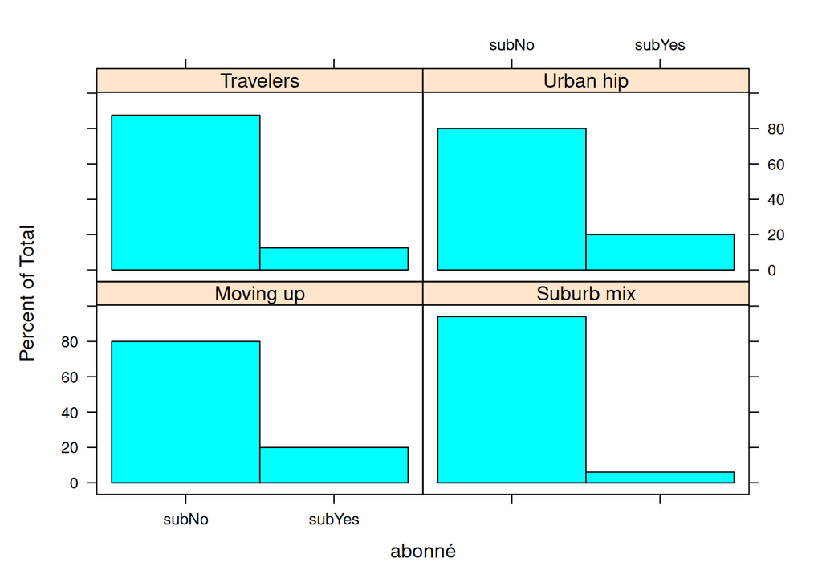

```r
library(lattice)
histogram(~abonné | segments , data = clients)
```

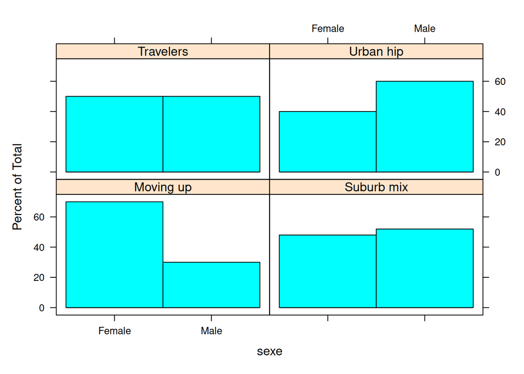

```r
histogram(~sexe | segments , data = clients)
```

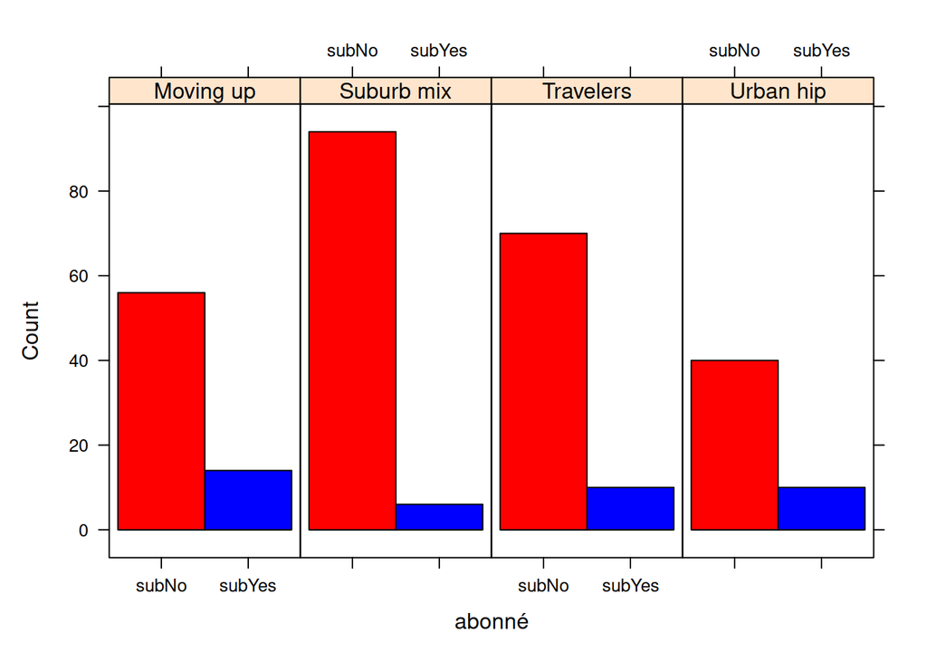

```r
histogram(~abonné|segments, data = clients, type = "count", layout=c(4,1),col=c("red","blue"))
```

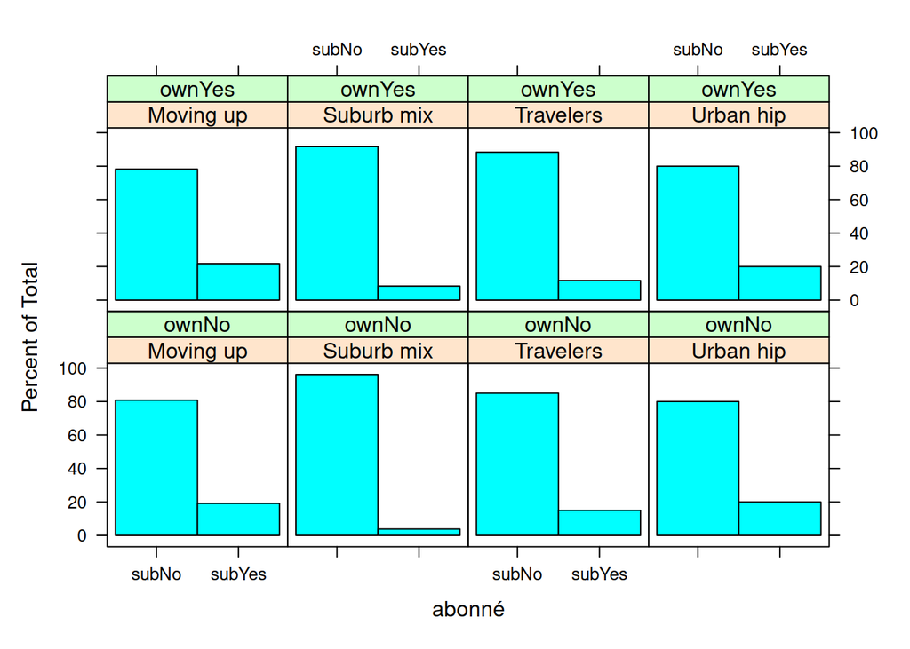

```r
histogram(~abonné | segments+proprio , data = clients)
```

```r
prop.table(table(clients$abonné,clients$segments),margin = 2)
```

```
##
##          Moving up Suburb mix Travelers Urban hip
##   subNo      0.800      0.940     0.875     0.800
##   subYes     0.200      0.060     0.125     0.200
```

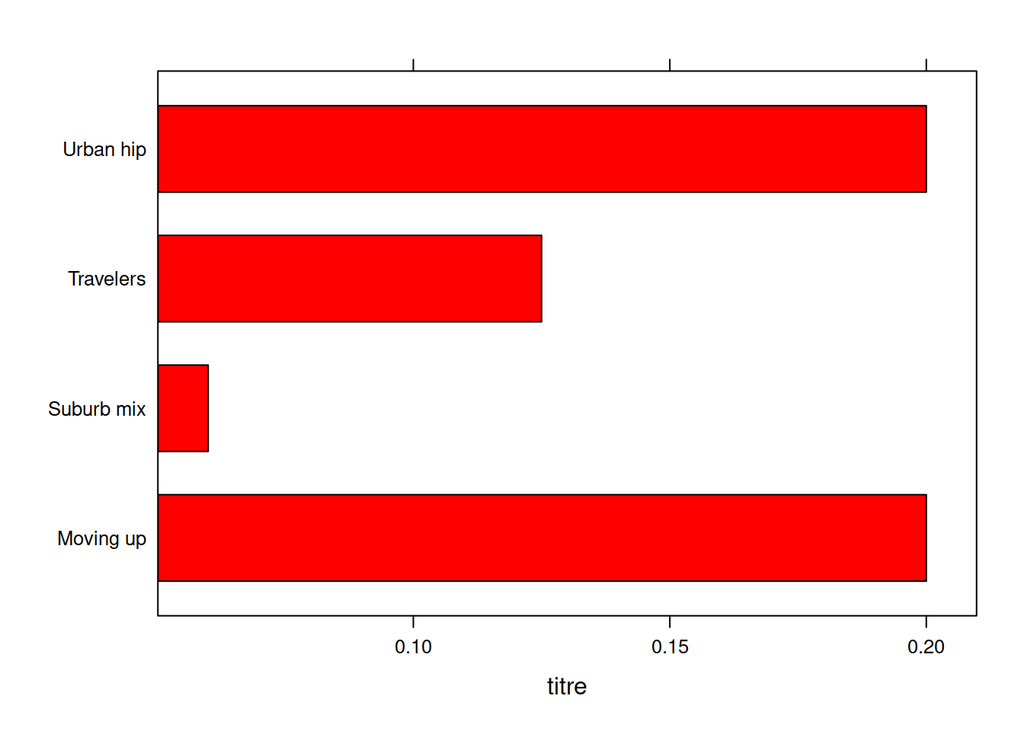

```r
#histogram(~abonné | segments+revenu.fac , data = clients)
barchart(prop.table(table(clients$abonné,clients$segments),margin = 2)[2,],xlab = "titre",col="red")
```

### essayons de realiser un test de comparaison des moyennes

##student dans notre bd

```r
by(clients$revenu,clients$proprio, var)
```

```
## clients$proprio: ownNo
## [1] 358692875
## ------------------------------------------------------------
## clients$proprio: ownYes
## [1] 430890091
```

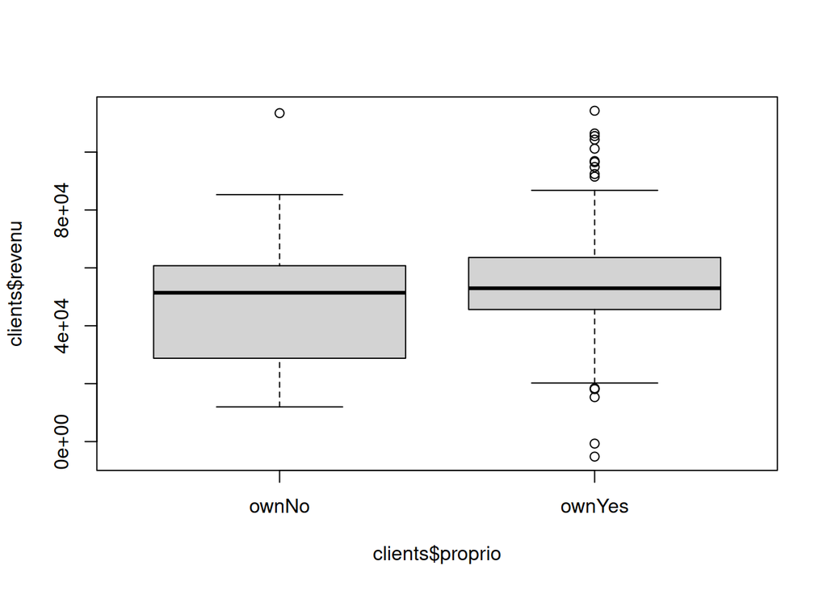

```r
boxplot(clients$revenu~clients$proprio)
```

visiblement les mean sont différente

# Vérification den la normalité

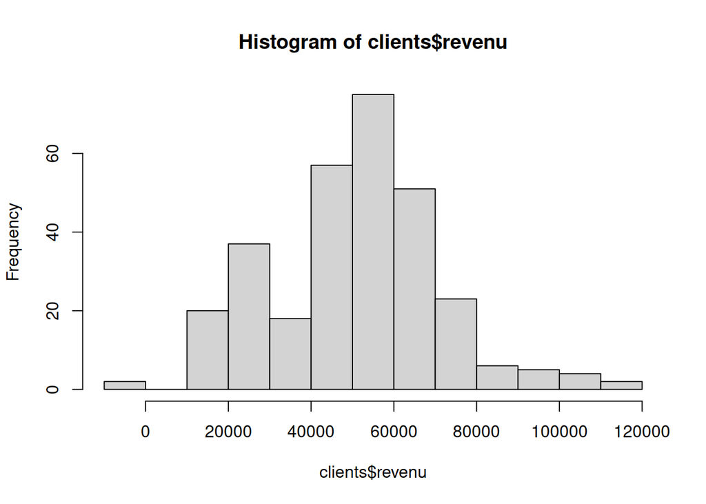

```r
hist(clients$revenu)
```

```r
shapiro.test(clients$revenu)
```

```
##
##  Shapiro-Wilk normality test
##
## data:  clients$revenu
## W = 0.97765, p-value = 0.0001244
```

normalité rejeté !!

pour visualiser la distribution d’une variable avec une seule modalite il faut:

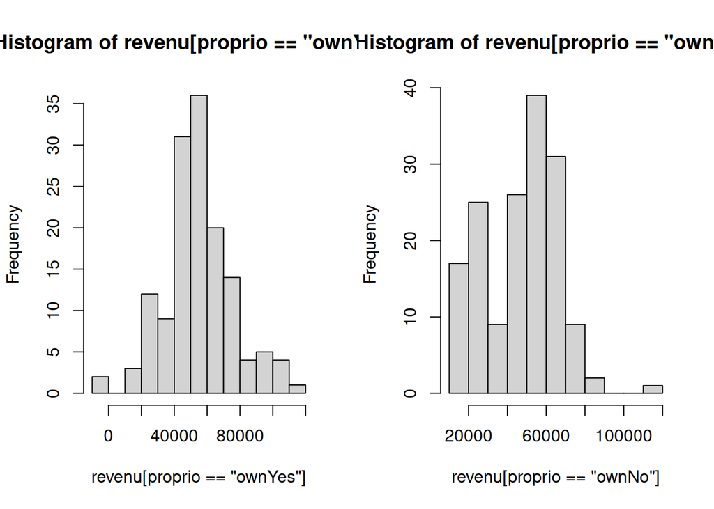

```r
par(mfrow=c(1,2))
with(clients,hist(revenu[proprio=="ownYes"]))
with(clients,hist(revenu[proprio=="ownNo"]))
```

```r
#t.test(clients$revenu~clients$proprio, var.equal=FALSE)
#lorsque les deux echantillon sont depezndant et numerique la syntaxe adequat est la suivante
#t.test(echan1,echan2, var.equal=T, paired=T)

#non paramétrique

by(clients$revenu,clients$proprio, median)
```

```
## clients$proprio: ownNo
## [1] 51412.56
## ------------------------------------------------------------
## clients$proprio: ownYes
## [1] 52953.41
```

```r
wilcox.test(clients$revenu~clients$proprio,correct = F)
```

```
##
##  Wilcoxon rank sum test
##
## data:  clients$revenu by clients$proprio
## W = 9325, p-value = 0.01197
## alternative hypothesis: true location shift is not equal to 0
```

rejet de H0

test de conformité

```r
median(clients$revenu)
```

```
## [1] 52014.35
```

```r
wilcox.test(clients$revenu, mu=52050)
```

```
##
##  Wilcoxon signed rank test with continuity correction
##
## data:  clients$revenu
## V = 21579, p-value = 0.508
## alternative hypothesis: true location is not equal to 52050
```

H0 accepté: oui le revenu moyen peut être assimilable/conforme a 52050

```r
library(pastecs)
by(clients$revenu,clients$proprio,stat.desc)
```

```
## clients$proprio: ownNo
##      nbr.val     nbr.null       nbr.na          min          max        range
## 1.590000e+02 0.000000e+00 0.000000e+00 1.198525e+04 1.134568e+05 1.014715e+05
##          sum       median         mean      SE.mean CI.mean.0.95          var
## 7.535171e+06 5.141256e+04 4.739101e+04 1.501975e+03 2.966540e+03 3.586929e+08
##      std.dev     coef.var
## 1.893919e+04 3.996367e-01
## ------------------------------------------------------------
## clients$proprio: ownYes
##       nbr.val      nbr.null        nbr.na           min           max
##  1.410000e+02  0.000000e+00  0.000000e+00 -5.183354e+03  1.142783e+05
##         range           sum        median          mean       SE.mean
##  1.194616e+05  7.745790e+06  5.295341e+04  5.493468e+04  1.748130e+03
##  CI.mean.0.95           var       std.dev      coef.var
##  3.456147e+03  4.308901e+08  2.075789e+04  3.778650e-01
```

##test du khi-deux lien entre deux var quali

#tableau de frequence

```r
t=table(clients$abonné,clients$proprio)
t
```

```
##
##          ownNo ownYes
##   subNo    137    123
##   subYes    22     18
```

HO: pas de lien H1: existance de lien Notons ici que le risque represente une ERREUR D’INFERENCE( donc en general c’est sur 100 echantillon je peux me tromper sur 5 echantillons)

```r
chisq.test(t,correct =F )
```

```
##
##  Pearson's Chi-squared test
##
## data:  t
## X-squared = 0.074113, df = 1, p-value = 0.7854
```

pas de lien !!!!

## passons au test binomiale sorti binaire

```r
#binom.test(x,n,p,alternative = "greater")
#?binom.test
# Supposons que nous avons 30 tirages de pièces de monnaie et que nous voulons tester si la probabilité de succès est de 0.5
nombre_de_succes <- 18
taille_de_l_echantillon <- 30
probabilite_theorique <- 0.5

# Effectuer le test binomial
resultat_test <- binom.test(nombre_de_succes, taille_de_l_echantillon, p = probabilite_theorique, alternative = "two.sided")

# Afficher les résultats
print(resultat_test)
```

```
##
##  Exact binomial test
##
## data:  nombre_de_succes and taille_de_l_echantillon
## number of successes = 18, number of trials = 30, p-value = 0.3616
## alternative hypothesis: true probability of success is not equal to 0.5
## 95 percent confidence interval:
##  0.4060349 0.7734424
## sample estimates:
## probability of success
##                    0.6
```

x:nbre observé qui repondent aux succeès , n:total , p=0.5(generalement), H1 (alternative)=superieure pour conclure on compare la prob de succes a 0.5

## ANOVA (analysis of variance)

il complète le test de stutend qui se limite a un facteur et 2 modalités *exclusivement*

*passons à la visualisation tout d’abord

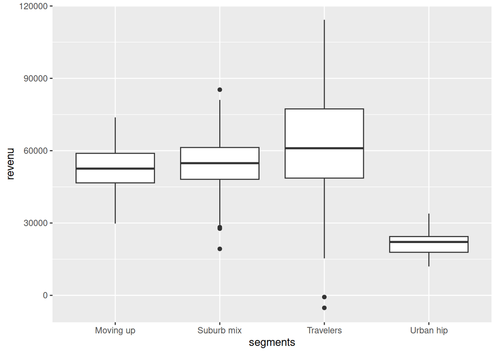

```r
library(ggplot2)
visua=ggplot(clients,aes(segments,revenu))+geom_boxplot()
visua
```

*passons a anova proprement dit ( un facteur plus de deux modalités)

```r
segmentanova=aov(revenu~segments,data = clients)

anova(segmentanova)
```

```
## Analysis of Variance Table
##
## Response: revenu
##            Df     Sum Sq    Mean Sq F value    Pr(>F)
## segments    3 5.4970e+10 1.8323e+10  81.828 < 2.2e-16 ***
## Residuals 296 6.6281e+10 2.2392e+08
## ---
## Signif. codes:  0 '***' 0.001 '**' 0.01 '*' 0.05 '.' 0.1 ' ' 1
```

F value est le quotient de la moyenne de la somme des carrées du model sur la moyenne de la somme des carrées par groupe

il est bien significatif donc on peut conclur que les types de segment ont un impact sur la moyenne des revenu

- anova deux facteurs now

```r
model2=aov(revenu~segments+proprio,data = clients)
anova(model2) #proprio pas significatif supsons de multicolinearité!!!!
```

```
## Analysis of Variance Table
##
## Response: revenu
##            Df     Sum Sq    Mean Sq F value Pr(>F)
## segments    3 5.4970e+10 1.8323e+10 81.6381 <2e-16 ***
## proprio     1 6.9918e+07 6.9918e+07  0.3115 0.5772
## Residuals 295 6.6211e+10 2.2444e+08
## ---
## Signif. codes:  0 '***' 0.001 '**' 0.01 '*' 0.05 '.' 0.1 ' ' 1
```

```r
model3=lm(revenu~segments+proprio,data = clients)
summary(model3)
```

```
##
## Call:
## lm(formula = revenu ~ segments + proprio, data = clients)
##
## Residuals:
##    Min     1Q Median     3Q    Max
## -67135  -6931   -270   6259  52327
##
## Coefficients:
##                    Estimate Std. Error t value Pr(>|t|)
## (Intercept)           53436       1894  28.208  < 2e-16 ***
## segmentsSuburb mix     2102       2352   0.894 0.372240
## segmentsTravelers      9566       2577   3.712 0.000246 ***
## segmentsUrban hip    -31544       2785 -11.328  < 2e-16 ***
## proprioownYes         -1050       1882  -0.558 0.577175
## ---
## Signif. codes:  0 '***' 0.001 '**' 0.01 '*' 0.05 '.' 0.1 ' ' 1
##
## Residual standard error: 14980 on 295 degrees of freedom
## Multiple R-squared:  0.4539, Adjusted R-squared:  0.4465
## F-statistic: 61.31 on 4 and 295 DF,  p-value: < 2.2e-16
```

*comparaison des modèles anova

```r
anova(segmentanova, model2)
```

```
## Analysis of Variance Table
##
## Model 1: revenu ~ segments
## Model 2: revenu ~ segments + proprio
##   Res.Df        RSS Df Sum of Sq      F Pr(>F)
## 1    296 6.6281e+10
## 2    295 6.6211e+10  1  69918004 0.3115 0.5772
```

Pr(F)= 0.5772 donc H0 accepté (pas d’amelioration dans le model ) model1 mieux que model2